# Estudio sobre la depresión estudiantil. Grupo 5. Estudio para la selección de k

Miguel Encina Martinez, Daniel Galván Cancio, Jaime Linares Barrera, Daniel Vela Camacho

# Selección del Valor K

El objetivo de este documento es determinar el número óptimo de clusters ($k$) para el análisis de segmentación. Para ello, emplearemos la métrica de **Suma de Cuadrados Intra-Cluster (WSS)**, buscando identificar el punto de inflexión o “codo” en la curva de compactación.

El análisis inicial se realiza sobre el dataset completo, el cual ha sido previamente sometido a un proceso de **One-Hot Encoding** para las variables categóricas y a una **estandarización** completa (media 0 y desviación típica 1). Esta transformación es crítica para cualquier algoritmo de aprendizaje no supervisado basado en distancias (como K-Means), ya que asegura que todas las variables contribuyan equitativamente al cálculo de similitud, independientemente de sus escalas originales.

## Carga y Preparación de Datos

Procedemos a cargar el dataset preprocesado y estandarizado:

```r
student_data <- read.csv("./data/student_depression_numeric_standard.csv")
```

Verificamos la estructura e integridad del dataset antes de proceder:

```r
head(student_data)
```

```
##          Age Academic.Pressure       CGPA Study.Satisfaction Sleep.Duration
## 1  1.4636878         1.3453951  0.8953448        -0.69391252     -0.3542413
## 2 -0.3706759        -0.8265708 -1.2008888         1.51119962     -0.3542413
## 3  1.0560514        -0.1025822 -0.4293109         1.51119962     -1.2418567
## 4  0.4445969        -0.1025822 -1.4125606        -0.69391252      0.5333740
## 5 -0.1668577         0.6214064  0.3217826         0.04112486     -0.3542413
## 6  0.6484151        -0.8265708 -1.3374512         0.04112486     -1.2418567
##   Dietary.Habits     Degree Had.suicidal.thoughts Work.Study.Hours
## 1      1.3748389 -0.1371477             0.7619473       -1.1226157
## 2      0.1199654 -0.1371477            -1.3123795       -1.1226157
## 3      1.3748389 -0.1371477            -1.3123795        0.4963858
## 4      0.1199654 -0.1371477             0.7619473       -0.8527821
## 5      0.1199654  1.1909865             0.7619473       -1.6622829
## 6      1.3748389  2.5191207            -1.3123795       -0.8527821
##   Financial.Stress Family.History.Mental.Illness Gender.Female Gender.Male
```

[output cut: 41 more lines]

Dado que el objetivo es realizar un **aprendizaje no supervisado** para descubrir patrones subyacentes, excluimos la variable objetivo `Depression` del conjunto de entrenamiento. Esta variable se reservará para fases posteriores de validación externa mediante conocimiento experto.

```r
student_data_clustering <- student_data %>%
  select(-Depression)
```

## Determinación de K mediante el Método del Codo (WSS)

La **Suma de Cuadrados Intra-Cluster (WSS)** cuantifica la variabilidad interna de los grupos: un valor menor indica clusters más compactos y homogéneos.

Matemáticamente, para una partición en $k$ clusters, el WSS se define como:

$$WSS = \sum_{j=1}^{k} \sum_{x_i \in C_j} \|x_i - \mu_j\|^2$$

Donde $C_j$ representa el cluster $j$, $\mu_j$ es el centroide de dicho cluster, y $x_i$ son las observaciones asignadas a él.

Buscamos identificar el “codo” de la curva: el punto a partir del cual el incremento en el número de clusters deja de aportar una reducción sustancial en la variabilidad interna (rendimientos decrecientes).

Calculamos el WSS para $k \in [1, 10]$ utilizando el algoritmo K-Means:

```r
vector_compactacion_full <- numeric(10)

set.seed(123)
for(i in 1:10){
  km_modelo <- kmeans(student_data_clustering,
                      centers = i,
                      iter.max = 500,
                      algorithm = "MacQueen",
                      nstart = 20)
  vector_compactacion_full[i] <- km_modelo$tot.withinss
}
```

Visualizamos la evolución de la compactación:

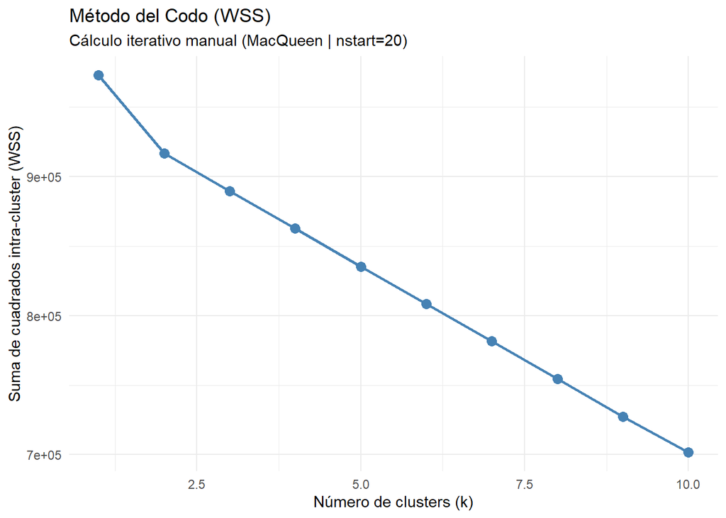

```r
elbow_data <- data.frame(
  k = 1:10,
  wss = vector_compactacion_full
)

ggplot(elbow_data, aes(x = k, y = wss)) +
  geom_line(color = "steelblue", size = 1) +
  geom_point(color = "steelblue", size = 3) +
  labs(title = "Método del Codo (WSS)",
       subtitle = "Cálculo iterativo manual (MacQueen | nstart=20)",
       x = "Número de clusters (k)",
       y = "Suma de cuadrados intra-cluster (WSS)") +
  theme_minimal()
```

### Justificación de parámetros del algoritmo

Se han ajustado los parámetros para priorizar la estabilidad y evitar óptimos locales en este espacio de alta dimensionalidad:

- **Algoritmo MacQueen**: Seleccionado por su actualización *online* de centroides, ofreciendo una convergencia más robusta en datos complejos.
- **`iter.max = 500`**: Incrementado para prevenir paradas prematuras y alertas de convergencia típicas de la configuración por defecto.
- **`nstart = 20`**: Crítico para mitigar el riesgo de óptimos locales y el ruido dimensional mediante múltiples reinicios aleatorios.

### Análisis de la curva de compactación

Como podemos ver en los datos graficados no es posible determinar un codo claro, por lo que procedemos a realizar el análisis de la métrica de Silhoutte a medida que incrementamos el número de clusters.

### Determinación de K mediante Silhoutte

El segundo criterio que utilizamos es el **Coeficiente de Silueta** (Silhouette Coefficient), una métrica que evalúa simultáneamente la cohesión interna de cada cluster y la separación respecto a los clusters vecinos.

Para cada observación $i$, el coeficiente de silueta $s(i)$ se calcula como:

$$s(i) = \frac{b(i) - a(i)}{\max\{a(i), b(i)\}}$$

donde:

- $a(i)$: distancia media de la observación $i$ a todas las demás observaciones de su mismo cluster (cohesión).
- $b(i)$: distancia media mínima de la observación $i$ a todas las observaciones del cluster más cercano que no es el suyo (separación).
- El valor de $s(i)$ oscila entre -1 y 1:

Valores **cercanos a +1** indican que la observación está **bien asignada** a su cluster.

Valores **cercanos a 0** sugieren que la observación se encuentra en la **frontera entre clusters**.

Valores **negativos** indican una posible **asignación errónea**.

### Uso de CLARA

El cálculo estándar del coeficiente de *silhoutte* requiere construir una matriz de disimilitud (distancias) de tamaño $N \times N$. Dado que nuestro dataset contiene aproximadamente $N \approx 28,000$ observaciones, esto implicaría una matriz de $28,000 \times 28,000 = 784,000,000$ elementos.

Desde el punto de vista computacional, esto presenta dos problemas críticos:

- **Complejidad espacial**: $O(N^2)$ en memoria. Almacenar esta matriz requeriría aproximadamente 6 GB de RAM solo para las distancias (asumiendo valores de 8 bytes en doble precisión), lo cual desbordaría la memoria disponible en la mayoría de sistemas.
- **Complejidad temporal**: El cálculo de todas las distancias por pares tiene complejidad $O(N^2)$, haciendo el proceso extremadamente lento para datasets de este tamaño.

Por este motivo, optamos por el algoritmo **CLARA (Clustering Large Applications)**. CLARA es una extensión del algoritmo PAM (Partitioning Around Medoids) diseñada específicamente para trabajar con grandes volúmenes de datos. Su estrategia consiste en:

1. Extraer múltiples submuestras aleatorias del dataset completo.
2. Aplicar el algoritmo PAM a cada submuestra para identificar medoides candidatos.
3. Evaluar la calidad de cada partición sobre el dataset completo.
4. Seleccionar la mejor partición encontrada.

Este enfoque permite aproximar la solución óptima global de manera eficiente y robusta, evitando el cuello de botella de memoria y tiempo que supondría el cálculo exacto sobre todos los datos.

Procedemos a calcular y visualizar el coeficiente de silueta medio para diferentes valores de $k$ utilizando CLARA:

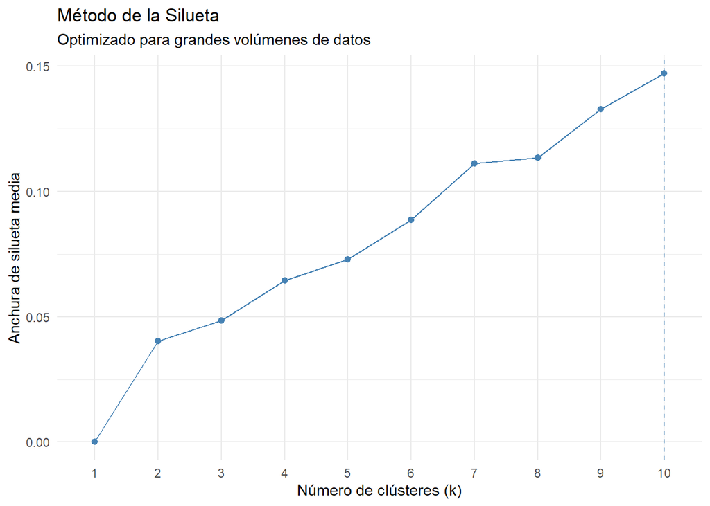

```r
fviz_nbclust(student_data_clustering, clara, method = "silhouette", k.max = 10) +
  labs(
    title = "Método de la Silueta",
    subtitle = "Optimizado para grandes volúmenes de datos",
    x = "Número de clústeres (k)",
    y = "Anchura de silueta media"
  ) +
  theme_minimal()
```

### Análisis de la curva de Silhouette

En los datos graficados, hemos de encontrar un maximo de la anchura de silueta media. Como podemos ver en los datos, la tendencia de los datos es creciente, por lo que no encontramos un máximo local / máximo global claro, que nos permita garantizar un valor determinado de $k$.

## Análisis de la dimensionalidad

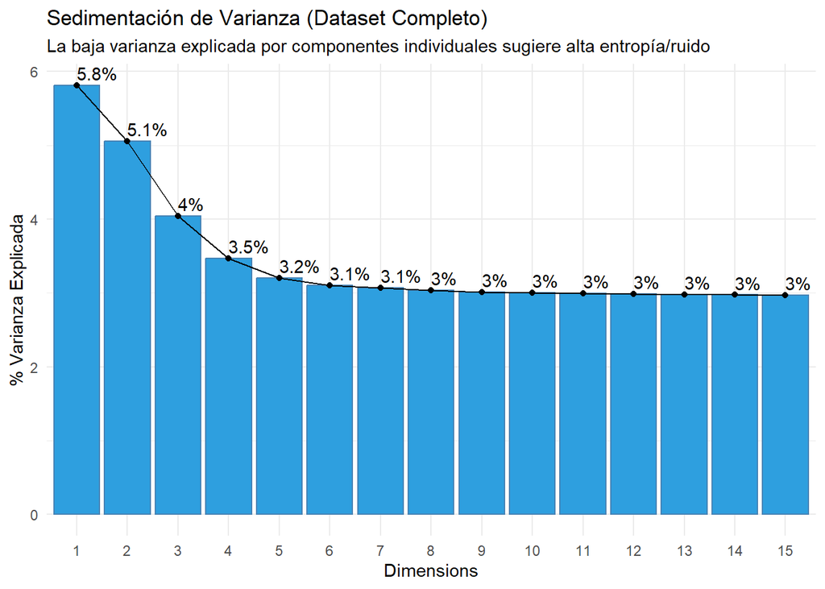

```r
# Diagnóstico de Varianza (PCA)
pca_check <- prcomp(student_data_clustering, scale. = FALSE)

fviz_eig(pca_check,
         ncp = 15,
         addlabels = TRUE,
         barfill = "#2E9FDF",
         linecolor = "black") +
  labs(title = "Sedimentación de Varianza (Dataset Completo)",
       subtitle = "La baja varianza explicada por componentes individuales sugiere alta entropía/ruido",
       y = "% Varianza Explicada") +
  theme_minimal()
```

### Interpretación del diagnóstico

La gráfica muestra una clara “dilución de la información”. Las primeras componentes explican un porcentaje muy bajo de la varianza total, lo que confirma que la información está fragmentada en demasiadas dimensiones (ruido), dificultando la formación de clusters densos.

### Información Mutua (MI)

Para resolver esto, **no utilizaremos reducción por proyección** (como PCA) para no perder **interpretabilidad clínica**. En su lugar, justificamos el uso del dataset reducido mediante **Información Mutua (Mutual Information)**.

MI nos permite filtrar las variables irrelevantes (ruido) y conservar solo aquellas con una dependencia estadística real con la estructura latente de los datos, reduciendo el espacio de búsqueda para K-Means/CLARA.

## Determinación de k en el Dataset Reducido (MI)

Procedemos a cargar el dataset resultante de la selección de características basada en Información Mutua.

```r
student_data_clustering_mi <- read.csv("./data/student_depression_numeric_standard_mi.csv")
head(student_data_clustering_mi)
```

```
##   Had.suicidal.thoughts Academic.Pressure Financial.Stress        Age
## 1             0.7619473         1.3453951        -1.488559  1.4636878
## 2            -1.3123795        -0.8265708        -0.792760 -0.3706759
## 3            -1.3123795        -0.1025822        -1.488559  1.0560514
## 4             0.7619473        -0.1025822         1.294638  0.4445969
## 5             0.7619473         0.6214064        -1.488559 -0.1668577
## 6            -1.3123795        -0.8265708        -1.488559  0.6484151
##   Work.Study.Hours Dietary.Habits Study.Satisfaction     Degree Sleep.Duration
## 1       -1.1226157      1.3748389        -0.69391252 -0.1371477     -0.3542413
## 2       -1.1226157      0.1199654         1.51119962 -0.1371477     -0.3542413
## 3        0.4963858      1.3748389         1.51119962 -0.1371477     -1.2418567
## 4       -0.8527821      0.1199654        -0.69391252 -0.1371477      0.5333740
## 5       -1.6622829      0.1199654         0.04112486  1.1909865     -0.3542413
## 6       -0.8527821      1.3748389         0.04112486  2.5191207     -1.2418567
##         CGPA Family.History.Mental.Illness Depression
## 1  0.8953448                    -0.9686312        Yes
## 2 -1.2008888                     1.0323475         No
## 3 -0.4293109                     1.0323475         No
## 4 -1.4125606                     1.0323475        Yes
## 5  0.3217826                    -0.9686312         No
## 6 -1.3374512                    -0.9686312         No
```

### Estrategia de Evaluación: Enfoque en Silueta

Para esta determinación final, descartamos el criterio del codo (WSS) dada su ambigüedad previa y basamos la decisión exclusivamente en el **Coeficiente de Silueta**. Esta métrica nos permite cuantificar objetivamente la calidad de la estructura encontrada, buscando la partición que maximice la distinción entre grupos.

Metodológicamente, mantenemos el uso de **CLARA** no por preferencia algorítmica, sino por estricta necesidad computacional: el volumen de datos ($N \approx 28,000$) implica una complejidad $O(N^2)$ en el cálculo de distancias. CLARA nos permite estimar la silueta de forma eficiente mediante muestreo, eludiendo las limitaciones de memoria de los algoritmos tradicionales.

### Estrategia de Validación Robusta: Prueba de Estrés del Muestreo

Es importante recordar que CLARA es un algoritmo estocástico; basa sus resultados en submuestras aleatorias del dataset original. Esto implica que una sola ejecución puede no ser fiable para determinar un $k$ definitivo, ya que podría estar sesgada por la muestra específica seleccionada.

Para mitigar este riesgo, implementamos una **Prueba de Estrés del Muestreo**. Compararemos la estabilidad de la métrica de Silueta bajo tres configuraciones de rigor creciente:

1. **Baja**: Muestreo rápido (Riesgo de óptimos locales).
2. **Media**: Configuración estándar.
3. **Alta**: Muestreo intensivo (Aproximación al óptimo global).

A continuación, ejecutamos el análisis de sensibilidad:

```r
resultados_sensibilidad <- data.frame()
k_rango <- 2:6

set.seed(123)

for(k in k_rango){

  modelo_bajo <- clara(student_data_clustering_mi, k = k, samples = 5, sampsize = 200)
  sil_bajo <- modelo_bajo$silinfo$avg.width

  modelo_medio <- clara(student_data_clustering_mi, k = k, samples = 20, sampsize = 1000)
  sil_medio <- modelo_medio$silinfo$avg.width

  modelo_alto <- clara(student_data_clustering_mi, k = k, samples = 50, sampsize = 3000)
  sil_alto <- modelo_alto$silinfo$avg.width

  resultados_sensibilidad <- rbind(resultados_sensibilidad, data.frame(
    k = k,
    Baja = sil_bajo,
    Media = sil_medio,
    Alta = sil_alto
  ))
}
```

Finalmente, visualizamos la convergencia de la métrica de silueta para evaluar la robustez de los clusters sugeridos:

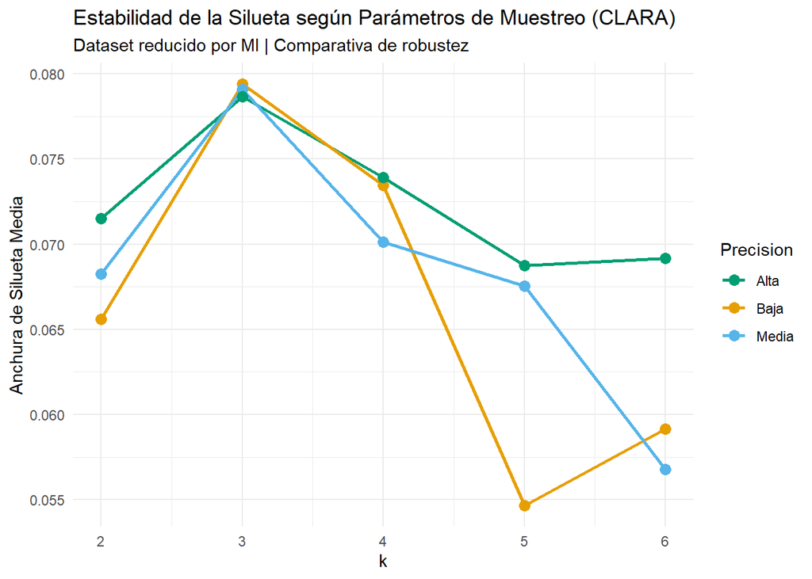

```r
resultados_long <- resultados_sensibilidad %>%
  pivot_longer(cols = c("Baja", "Media", "Alta"), names_to = "Precision", values_to = "Silueta")

ggplot(resultados_long, aes(x = k, y = Silueta, color = Precision)) +
  geom_line(size = 1) +
  geom_point(size = 3) +
  scale_color_manual(values = c("Baja" = "#E69F00", "Media" = "#56B4E9", "Alta" = "#009E73")) +
  labs(title = "Estabilidad de la Silueta según Parámetros de Muestreo (CLARA)",
       subtitle = "Dataset reducido por MI | Comparativa de robustez",
       y = "Anchura de Silueta Media") +
  theme_minimal()
```

1. **Validación para usar K-Medoids**:

   La aparición natural de tres grupos diferenciados apoya estadísticamente una hipótesis clínica para el estudio de la depresión. Es altamente posibleque esta estructura basada en tres grupos refleje una agrupación basada en la severidad:
   - **Grupo 1:** Riesgo Bajo / Control.
   - **Grupo 2:** Riesgo Moderado / Vulnerable.
   - **Grupo 3:** Riesgo Alto / Crítico.

Por ello es que concluimos realizar el modelado final utilizando el algoritmo CLARA con $k=3$, con el objetivo de extraer los medoides y caracterizar los perfiles de riesgo en la siguiente fase del estudio.